```python
# conda install -c conda-forge pandas-profiling
# conda update -n base -c defaults conda
```

```python
# importing libraries
import pandas_profiling
import numpy as np
import pandas as pd
from sklearn.tree import DecisionTreeRegressor
from sklearn.tree import DecisionTreeClassifier
from sklearn.model_selection import GridSearchCV, cross_val_score
from sklearn.preprocessing import LabelEncoder
from sklearn.ensemble import RandomForestClassifier
from sklearn.ensemble import RandomForestRegressor
from sklearn.metrics  import  mean_squared_error as mse
from sklearn.ensemble import AdaBoostRegressor
from sklearn.ensemble import AdaBoostClassifier
from sklearn import metrics
import matplotlib.pyplot as plt
from collections import Counter
from matplotlib import cm
from sklearn import datasets
from sklearn.metrics import confusion_matrix
from sklearn.neighbors import KNeighborsClassifier
from sklearn.model_selection import train_test_split
import seaborn as sns
from sklearn.cluster import KMeans
from scipy.spatial.distance import cdist
from sklearn.decomposition import PCA
import networkx as nx
# from community import best_partition
import scipy.cluster.hierarchy as sch
from sklearn.cluster import AgglomerativeClustering
import math
import re
from sklearn.svm import SVC
from sklearn.neighbors import KNeighborsClassifier
from sklearn.metrics import accuracy_score
from sklearn import decomposition
from sklearn import datasets
from mpl_toolkits.mplot3d import Axes3D
from sklearn.decomposition import PCA
%matplotlib inline
```

# Methods we will use more the once:

```python
RSEED = 50

### Plotting Categorical Features
# Looping through and Plotting Categorical features
def plotForSibSpAndParch(coulmnName):

    # Figure initiation
    fig = plt.figure(figsize=(18,18))

    ### Number of occurrences per categoty - target pair
    ax = sns.countplot(x=coulmnName, hue="Survived", data=TrainDF, ax = plt.subplot(312));
    # X-axis Label
    plt.xlabel(coulmnName, fontsize=14);
    # Y-axis Label
    plt.ylabel('Number of occurrences', fontsize=14);
    # Setting Legend location
    plt.legend(loc=1);

    ### Adding percents over bars
    # Getting heights of our bars
    height = [p.get_height() if p.get_height()==p.get_height() else 0 for p in ax.patches]
    # Counting number of bar groups
    ncol = int(len(height)/2)
    # Counting total height of groups
    total = [height[i] + height[i + ncol] for i in range(ncol)] * 2
    # Looping through bars
    for i, p in enumerate(ax.patches):
        # Adding percentages
        ax.text(p.get_x()+p.get_width()/2, height[i]*1.01 + 10,
                '{:1.0%}'.format(height[i]/total[i]), ha="center", size=14)

# this method will help us to check if there are NULL values in our data
def null_table(training, testing):
    print("Training Data Frame")
    print(pd.isnull(training).sum())
    print(" ")
    print("Testing Data Frame")
    print(pd.isnull(testing).sum())

# method to transform all categorialfeatures
def transformCategoricalFeatures(df):
    k = list(df.columns)
    count = 0
    for column in df.columns:
        if isinstance(df[column].unique()[0], str):
            y = df[column].unique()
            encode = LabelEncoder()
            encode.fit(df[column].astype(str))
            df[column] = encode.transform(df[column].astype(str))
            x = df[column].unique()

# method that creates a CSV file with the right model name
def Create_Prediction_File(name , prediction):
    submission = pd.DataFrame({
            "PassengerId": TestDF["PassengerId"],
            "Survived": prediction
        })
    path = 'ML_HW3\\'+ name + '_Prediction.csv'
    submission.to_csv(path, index=False)
```

# Extracting the datasets

```python
# Upload datasets from csv files
TrainDF = pd.read_csv("ML_HW3\\train.csv")
TestDF = pd.read_csv("ML_HW3\\test.csv")
```

##### Profiling the data: Traind and Test dataset

- Each features will have the following values:

  count, distinct_count, p_missing, n_missing, p_infinite, n_infinite, is_unique, mode, p_unique, memorysize, type, top, freq, mean, std, variance, min, max, range, 5%, '25%', 50%, 75%, 95%, iqr, kurtosis, skewness, sum, mad, cv, n_zeros, p_zeros, histogram, mini_histogram

```python
# We create a profiling Report on our data - this profiling will give aמ examination about our data and its features.
profileTrain = pandas_profiling.ProfileReport(TrainDF)
profileTest = pandas_profiling.ProfileReport(TestDF)
```

Dataset info

| Number of variables | 12 |
| --- | --- |
| Number of observations | 891 |
| Total Missing (%) | 8.1% |
| Total size in memory | 83.7 KiB |
| Average record size in memory | 96.1 B |

Variables types

| Numeric | 6 |
| --- | --- |
| Categorical | 4 |
| Boolean | 1 |
| Date | 0 |
| Text (Unique) | 1 |
| Rejected | 0 |
| Unsupported | 0 |

Warnings

- `Age` has 177 / 19.9% missing values Missing

- `SibSp` has 608 / 68.2% zeros Zeros

- `Parch` has 678 / 76.1% zeros Zeros

- `Ticket` has a high cardinality: 681 distinct values Warning

- `Fare` has 15 / 1.7% zeros Zeros

- `Cabin` has 687 / 77.1% missing values Missing

- `Cabin` has a high cardinality: 148 distinct values Warning

Variables

PassengerId  
Numeric

| Distinct count | 891 |
| --- | --- |
| Unique (%) | 100.0% |
| Missing (%) | 0.0% |
| Missing (n) | 0 |
| Infinite (%) | 0.0% |
| Infinite (n) | 0 |

| Mean | 446 |
| --- | --- |
| Minimum | 1 |
| Maximum | 891 |
| Zeros (%) | 0.0% |

Toggle details

**Statistics**

Quantile statistics

| Minimum | 1 |
| --- | --- |
| 5-th percentile | 45.5 |
| Q1 | 223.5 |
| Median | 446 |
| Q3 | 668.5 |
| 95-th percentile | 846.5 |
| Maximum | 891 |
| Range | 890 |
| Interquartile range | 445 |

Descriptive statistics

| Standard deviation | 257.35 |
| --- | --- |
| Coef of variation | 0.57703 |
| Kurtosis | -1.2 |
| Mean | 446 |
| MAD | 222.75 |
| Skewness | 0 |
| Sum | 397386 |
| Variance | 66231 |
| Memory size | 7.1 KiB |

**Histogram**

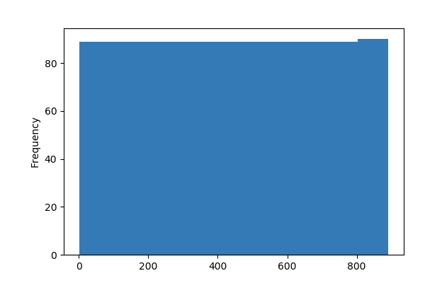

**Common Values**

| Value | Count | Frequency (%) |  |
| --- | --- | --- | --- |
| 891 | 1 | 0.1% |  |
| 293 | 1 | 0.1% |  |
| 304 | 1 | 0.1% |  |
| 303 | 1 | 0.1% |  |
| 302 | 1 | 0.1% |  |
| 301 | 1 | 0.1% |  |
| 300 | 1 | 0.1% |  |
| 299 | 1 | 0.1% |  |
| 298 | 1 | 0.1% |  |
| 297 | 1 | 0.1% |  |
| Other values (881) | 881 | 98.9% |  |

**Extreme Values**

Minimum 5 values

| Value | Count | Frequency (%) |  |
| --- | --- | --- | --- |
| 1 | 1 | 0.1% |  |
| 2 | 1 | 0.1% |  |
| 3 | 1 | 0.1% |  |
| 4 | 1 | 0.1% |  |
| 5 | 1 | 0.1% |  |

Maximum 5 values

| Value | Count | Frequency (%) |  |
| --- | --- | --- | --- |
| 887 | 1 | 0.1% |  |
| 888 | 1 | 0.1% |  |
| 889 | 1 | 0.1% |  |
| 890 | 1 | 0.1% |  |
| 891 | 1 | 0.1% |  |

Survived  
Boolean

| Distinct count | 2 |
| --- | --- |
| Unique (%) | 0.2% |
| Missing (%) | 0.0% |
| Missing (n) | 0 |

| Mean | 0.38384 |
| --- | --- |

| 0 | 549 |
| --- | --- |
| 1 | 342 |

Toggle details

| Value | Count | Frequency (%) |  |
| --- | --- | --- | --- |
| 0 | 549 | 61.6% |  |
| 1 | 342 | 38.4% |  |

Pclass  
Numeric

| Distinct count | 3 |
| --- | --- |
| Unique (%) | 0.3% |
| Missing (%) | 0.0% |
| Missing (n) | 0 |
| Infinite (%) | 0.0% |
| Infinite (n) | 0 |

| Mean | 2.3086 |
| --- | --- |
| Minimum | 1 |
| Maximum | 3 |
| Zeros (%) | 0.0% |

Toggle details

**Statistics**

Quantile statistics

| Minimum | 1 |
| --- | --- |
| 5-th percentile | 1 |
| Q1 | 2 |
| Median | 3 |
| Q3 | 3 |
| 95-th percentile | 3 |
| Maximum | 3 |
| Range | 2 |
| Interquartile range | 1 |

Descriptive statistics

| Standard deviation | 0.83607 |
| --- | --- |
| Coef of variation | 0.36215 |
| Kurtosis | -1.28 |
| Mean | 2.3086 |
| MAD | 0.76197 |
| Skewness | -0.63055 |
| Sum | 2057 |
| Variance | 0.69902 |
| Memory size | 7.1 KiB |

**Histogram**

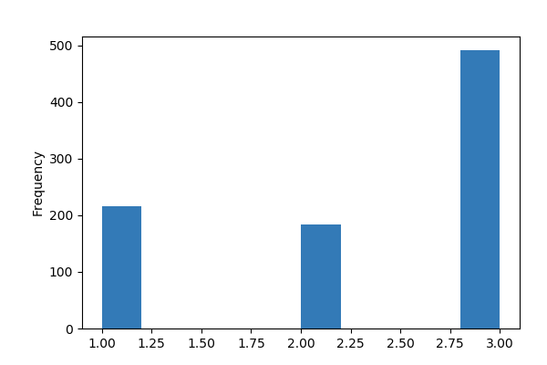

**Common Values**

| Value | Count | Frequency (%) |  |
| --- | --- | --- | --- |
| 3 | 491 | 55.1% |  |
| 1 | 216 | 24.2% |  |
| 2 | 184 | 20.7% |  |

**Extreme Values**

Minimum 5 values

| Value | Count | Frequency (%) |  |
| --- | --- | --- | --- |
| 1 | 216 | 24.2% |  |
| 2 | 184 | 20.7% |  |
| 3 | 491 | 55.1% |  |

Maximum 5 values

| Value | Count | Frequency (%) |  |
| --- | --- | --- | --- |
| 1 | 216 | 24.2% |  |
| 2 | 184 | 20.7% |  |
| 3 | 491 | 55.1% |  |

Name  
Categorical, Unique

| First 3 values |
| --- |
| Blackwell, Mr. Stephen Weart |
| Sadlier, Mr. Matthew |
| Zabour, Miss. Thamine |

| Last 3 values |
| --- |
| Van der hoef, Mr. Wyckoff |
| Morley, Mr. Henry Samuel ("Mr Henry Marshall") |
| Kirkland, Rev. Charles Leonard |

Toggle details

First 10 values

| Value | Count | Frequency (%) |  |
| --- | --- | --- | --- |
| Abbing, Mr. Anthony | 1 | 0.1% |  |
| Abbott, Mr. Rossmore Edward | 1 | 0.1% |  |
| Abbott, Mrs. Stanton (Rosa Hunt) | 1 | 0.1% |  |
| Abelson, Mr. Samuel | 1 | 0.1% |  |
| Abelson, Mrs. Samuel (Hannah Wizosky) | 1 | 0.1% |  |

Last 10 values

| Value | Count | Frequency (%) |  |
| --- | --- | --- | --- |
| de Mulder, Mr. Theodore | 1 | 0.1% |  |
| de Pelsmaeker, Mr. Alfons | 1 | 0.1% |  |
| del Carlo, Mr. Sebastiano | 1 | 0.1% |  |
| van Billiard, Mr. Austin Blyler | 1 | 0.1% |  |
| van Melkebeke, Mr. Philemon | 1 | 0.1% |  |

Sex  
Categorical

| Distinct count | 2 |
| --- | --- |
| Unique (%) | 0.2% |
| Missing (%) | 0.0% |
| Missing (n) | 0 |

| male | 577 |
| --- | --- |
| female | 314 |

Toggle details

| Value | Count | Frequency (%) |  |
| --- | --- | --- | --- |
| male | 577 | 64.8% |  |
| female | 314 | 35.2% |  |

Age  
Numeric

| Distinct count | 89 |
| --- | --- |
| Unique (%) | 10.0% |
| Missing (%) | 19.9% |
| Missing (n) | 177 |
| Infinite (%) | 0.0% |
| Infinite (n) | 0 |

| Mean | 29.699 |
| --- | --- |
| Minimum | 0.42 |
| Maximum | 80 |
| Zeros (%) | 0.0% |

Toggle details

**Statistics**

Quantile statistics

| Minimum | 0.42 |
| --- | --- |
| 5-th percentile | 4 |
| Q1 | 20.125 |
| Median | 28 |
| Q3 | 38 |
| 95-th percentile | 56 |
| Maximum | 80 |
| Range | 79.58 |
| Interquartile range | 17.875 |

Descriptive statistics

| Standard deviation | 14.526 |
| --- | --- |
| Coef of variation | 0.48912 |
| Kurtosis | 0.17827 |
| Mean | 29.699 |
| MAD | 11.323 |
| Skewness | 0.38911 |
| Sum | 21205 |
| Variance | 211.02 |
| Memory size | 7.1 KiB |

**Histogram**

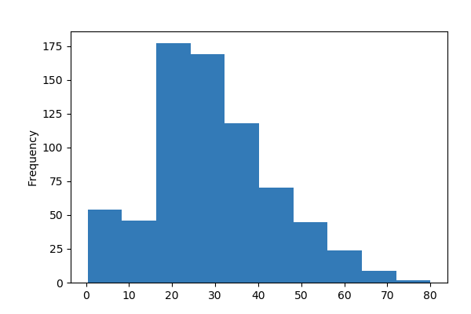

**Common Values**

| Value | Count | Frequency (%) |  |
| --- | --- | --- | --- |
| 24.0 | 30 | 3.4% |  |
| 22.0 | 27 | 3.0% |  |
| 18.0 | 26 | 2.9% |  |
| 28.0 | 25 | 2.8% |  |
| 19.0 | 25 | 2.8% |  |
| 30.0 | 25 | 2.8% |  |
| 21.0 | 24 | 2.7% |  |
| 25.0 | 23 | 2.6% |  |
| 36.0 | 22 | 2.5% |  |
| 29.0 | 20 | 2.2% |  |
| Other values (78) | 467 | 52.4% |  |
| (Missing) | 177 | 19.9% |  |

**Extreme Values**

Minimum 5 values

| Value | Count | Frequency (%) |  |
| --- | --- | --- | --- |
| 0.42 | 1 | 0.1% |  |
| 0.67 | 1 | 0.1% |  |
| 0.75 | 2 | 0.2% |  |
| 0.83 | 2 | 0.2% |  |
| 0.92 | 1 | 0.1% |  |

Maximum 5 values

| Value | Count | Frequency (%) |  |
| --- | --- | --- | --- |
| 70.0 | 2 | 0.2% |  |
| 70.5 | 1 | 0.1% |  |
| 71.0 | 2 | 0.2% |  |
| 74.0 | 1 | 0.1% |  |
| 80.0 | 1 | 0.1% |  |

SibSp  
Numeric

| Distinct count | 7 |
| --- | --- |
| Unique (%) | 0.8% |
| Missing (%) | 0.0% |
| Missing (n) | 0 |
| Infinite (%) | 0.0% |
| Infinite (n) | 0 |

| Mean | 0.52301 |
| --- | --- |
| Minimum | 0 |
| Maximum | 8 |
| Zeros (%) | 68.2% |

Toggle details

**Statistics**

Quantile statistics

| Minimum | 0 |
| --- | --- |
| 5-th percentile | 0 |
| Q1 | 0 |
| Median | 0 |
| Q3 | 1 |
| 95-th percentile | 3 |
| Maximum | 8 |
| Range | 8 |
| Interquartile range | 1 |

Descriptive statistics

| Standard deviation | 1.1027 |
| --- | --- |
| Coef of variation | 2.1085 |
| Kurtosis | 17.88 |
| Mean | 0.52301 |
| MAD | 0.71378 |
| Skewness | 3.6954 |
| Sum | 466 |
| Variance | 1.216 |
| Memory size | 7.1 KiB |

**Histogram**

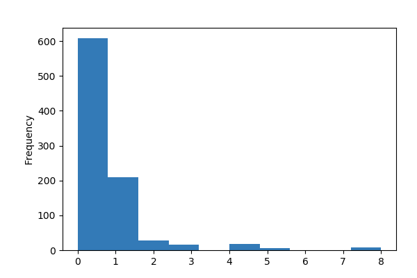

**Common Values**

| Value | Count | Frequency (%) |  |
| --- | --- | --- | --- |
| 0 | 608 | 68.2% |  |
| 1 | 209 | 23.5% |  |
| 2 | 28 | 3.1% |  |
| 4 | 18 | 2.0% |  |
| 3 | 16 | 1.8% |  |
| 8 | 7 | 0.8% |  |
| 5 | 5 | 0.6% |  |

**Extreme Values**

Minimum 5 values

| Value | Count | Frequency (%) |  |
| --- | --- | --- | --- |
| 0 | 608 | 68.2% |  |
| 1 | 209 | 23.5% |  |
| 2 | 28 | 3.1% |  |
| 3 | 16 | 1.8% |  |
| 4 | 18 | 2.0% |  |

Maximum 5 values

| Value | Count | Frequency (%) |  |
| --- | --- | --- | --- |
| 2 | 28 | 3.1% |  |
| 3 | 16 | 1.8% |  |
| 4 | 18 | 2.0% |  |
| 5 | 5 | 0.6% |  |
| 8 | 7 | 0.8% |  |

Parch  
Numeric

| Distinct count | 7 |
| --- | --- |
| Unique (%) | 0.8% |
| Missing (%) | 0.0% |
| Missing (n) | 0 |
| Infinite (%) | 0.0% |
| Infinite (n) | 0 |

| Mean | 0.38159 |
| --- | --- |
| Minimum | 0 |
| Maximum | 6 |
| Zeros (%) | 76.1% |

Toggle details

**Statistics**

Quantile statistics

| Minimum | 0 |
| --- | --- |
| 5-th percentile | 0 |
| Q1 | 0 |
| Median | 0 |
| Q3 | 0 |
| 95-th percentile | 2 |
| Maximum | 6 |
| Range | 6 |
| Interquartile range | 0 |

Descriptive statistics

| Standard deviation | 0.80606 |
| --- | --- |
| Coef of variation | 2.1123 |
| Kurtosis | 9.7781 |
| Mean | 0.38159 |
| MAD | 0.58074 |
| Skewness | 2.7491 |
| Sum | 340 |
| Variance | 0.64973 |
| Memory size | 7.1 KiB |

**Histogram**

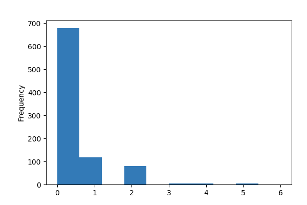

**Common Values**

| Value | Count | Frequency (%) |  |
| --- | --- | --- | --- |
| 0 | 678 | 76.1% |  |
| 1 | 118 | 13.2% |  |
| 2 | 80 | 9.0% |  |
| 5 | 5 | 0.6% |  |
| 3 | 5 | 0.6% |  |
| 4 | 4 | 0.4% |  |
| 6 | 1 | 0.1% |  |

**Extreme Values**

Minimum 5 values

| Value | Count | Frequency (%) |  |
| --- | --- | --- | --- |
| 0 | 678 | 76.1% |  |
| 1 | 118 | 13.2% |  |
| 2 | 80 | 9.0% |  |
| 3 | 5 | 0.6% |  |
| 4 | 4 | 0.4% |  |

Maximum 5 values

| Value | Count | Frequency (%) |  |
| --- | --- | --- | --- |
| 2 | 80 | 9.0% |  |
| 3 | 5 | 0.6% |  |
| 4 | 4 | 0.4% |  |
| 5 | 5 | 0.6% |  |
| 6 | 1 | 0.1% |  |

Ticket  
Categorical

| Distinct count | 681 |
| --- | --- |
| Unique (%) | 76.4% |
| Missing (%) | 0.0% |
| Missing (n) | 0 |

| 347082 | 7 |
| --- | --- |
| 1601 | 7 |
| CA. 2343 | 7 |
| Other values (678) | 870 |

Toggle details

| Value | Count | Frequency (%) |  |
| --- | --- | --- | --- |
| 347082 | 7 | 0.8% |  |
| 1601 | 7 | 0.8% |  |
| CA. 2343 | 7 | 0.8% |  |
| 3101295 | 6 | 0.7% |  |
| 347088 | 6 | 0.7% |  |
| CA 2144 | 6 | 0.7% |  |
| S.O.C. 14879 | 5 | 0.6% |  |
| 382652 | 5 | 0.6% |  |
| 2666 | 4 | 0.4% |  |
| LINE | 4 | 0.4% |  |
| Other values (671) | 834 | 93.6% |  |

Fare  
Numeric

| Distinct count | 248 |
| --- | --- |
| Unique (%) | 27.8% |
| Missing (%) | 0.0% |
| Missing (n) | 0 |
| Infinite (%) | 0.0% |
| Infinite (n) | 0 |

| Mean | 32.204 |
| --- | --- |
| Minimum | 0 |
| Maximum | 512.33 |
| Zeros (%) | 1.7% |

Toggle details

**Statistics**

Quantile statistics

| Minimum | 0 |
| --- | --- |
| 5-th percentile | 7.225 |
| Q1 | 7.9104 |
| Median | 14.454 |
| Q3 | 31 |
| 95-th percentile | 112.08 |
| Maximum | 512.33 |
| Range | 512.33 |
| Interquartile range | 23.09 |

Descriptive statistics

| Standard deviation | 49.693 |
| --- | --- |
| Coef of variation | 1.5431 |
| Kurtosis | 33.398 |
| Mean | 32.204 |
| MAD | 28.164 |
| Skewness | 4.7873 |
| Sum | 28694 |
| Variance | 2469.4 |
| Memory size | 7.1 KiB |

**Histogram**

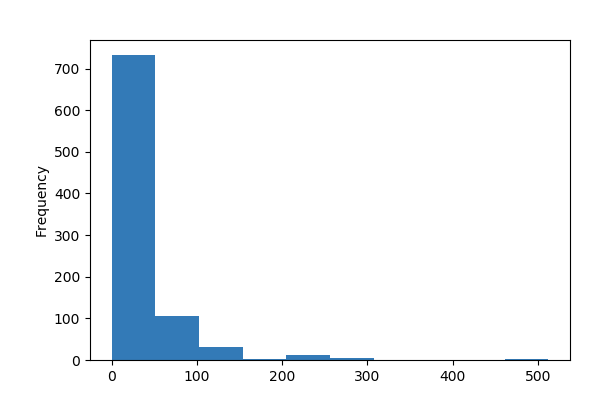

**Common Values**

| Value | Count | Frequency (%) |  |
| --- | --- | --- | --- |
| 8.05 | 43 | 4.8% |  |
| 13.0 | 42 | 4.7% |  |
| 7.8958 | 38 | 4.3% |  |
| 7.75 | 34 | 3.8% |  |
| 26.0 | 31 | 3.5% |  |
| 10.5 | 24 | 2.7% |  |
| 7.925 | 18 | 2.0% |  |
| 7.775 | 16 | 1.8% |  |
| 26.55 | 15 | 1.7% |  |
| 0.0 | 15 | 1.7% |  |
| Other values (238) | 615 | 69.0% |  |

**Extreme Values**

Minimum 5 values

| Value | Count | Frequency (%) |  |
| --- | --- | --- | --- |
| 0.0 | 15 | 1.7% |  |
| 4.0125 | 1 | 0.1% |  |
| 5.0 | 1 | 0.1% |  |
| 6.2375 | 1 | 0.1% |  |
| 6.4375 | 1 | 0.1% |  |

Maximum 5 values

| Value | Count | Frequency (%) |  |
| --- | --- | --- | --- |
| 227.525 | 4 | 0.4% |  |
| 247.5208 | 2 | 0.2% |  |
| 262.375 | 2 | 0.2% |  |
| 263.0 | 4 | 0.4% |  |
| 512.3292 | 3 | 0.3% |  |

Cabin  
Categorical

| Distinct count | 148 |
| --- | --- |
| Unique (%) | 16.6% |
| Missing (%) | 77.1% |
| Missing (n) | 687 |

| G6 | 4 |
| --- | --- |
| C23 C25 C27 | 4 |
| B96 B98 | 4 |
| Other values (144) | 192 |
| (Missing) | 687 |

Toggle details

| Value | Count | Frequency (%) |  |
| --- | --- | --- | --- |
| G6 | 4 | 0.4% |  |
| C23 C25 C27 | 4 | 0.4% |  |
| B96 B98 | 4 | 0.4% |  |
| E101 | 3 | 0.3% |  |
| F33 | 3 | 0.3% |  |
| D | 3 | 0.3% |  |
| C22 C26 | 3 | 0.3% |  |
| F2 | 3 | 0.3% |  |
| D20 | 2 | 0.2% |  |
| D26 | 2 | 0.2% |  |
| Other values (137) | 173 | 19.4% |  |
| (Missing) | 687 | 77.1% |  |

Embarked  
Categorical

| Distinct count | 4 |
| --- | --- |
| Unique (%) | 0.4% |
| Missing (%) | 0.2% |
| Missing (n) | 2 |

| S | 644 |
| --- | --- |
| C | 168 |
| Q | 77 |
| (Missing) | 2 |

Toggle details

| Value | Count | Frequency (%) |  |
| --- | --- | --- | --- |
| S | 644 | 72.3% |  |
| C | 168 | 18.9% |  |
| Q | 77 | 8.6% |  |
| (Missing) | 2 | 0.2% |  |

Correlations

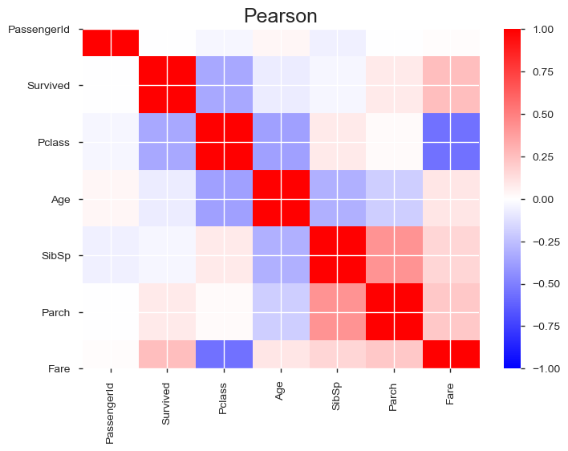

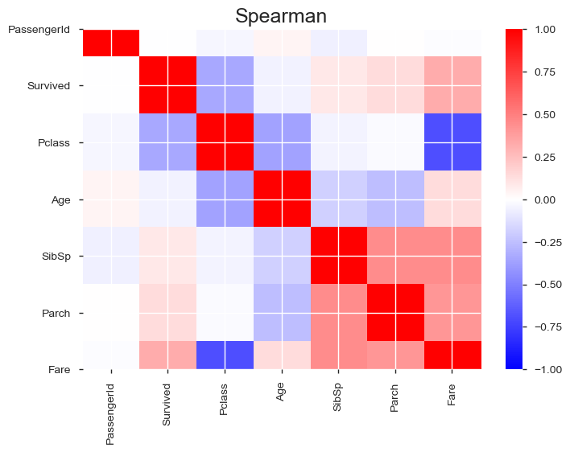

Sample

|  | PassengerId | Survived | Pclass | Name | Sex | Age | SibSp | Parch | Ticket | Fare | Cabin | Embarked |
| --- | --- | --- | --- | --- | --- | --- | --- | --- | --- | --- | --- | --- |
| 0 | 1 | 0 | 3 | Braund, Mr. Owen Harris | male | 22.0 | 1 | 0 | A/5 21171 | 7.2500 | NaN | S |
| 1 | 2 | 1 | 1 | Cumings, Mrs. John Bradley (Florence Briggs Thayer) | female | 38.0 | 1 | 0 | PC 17599 | 71.2833 | C85 | C |
| 2 | 3 | 1 | 3 | Heikkinen, Miss. Laina | female | 26.0 | 0 | 0 | STON/O2. 3101282 | 7.9250 | NaN | S |
| 3 | 4 | 1 | 1 | Futrelle, Mrs. Jacques Heath (Lily May Peel) | female | 35.0 | 1 | 0 | 113803 | 53.1000 | C123 | S |
| 4 | 5 | 0 | 3 | Allen, Mr. William Henry | male | 35.0 | 0 | 0 | 373450 | 8.0500 | NaN | S |

```python
profileTrain
```

```python
profileTrain.get_description()["variables"].columns
```

```
Index(['count', 'distinct_count', 'p_missing', 'n_missing', 'p_infinite',
       'n_infinite', 'is_unique', 'mode', 'p_unique', 'memorysize', 'type',
       'top', 'freq', 'mean', 'std', 'variance', 'min', 'max', 'range', '5%',
       '25%', '50%', '75%', '95%', 'iqr', 'kurtosis', 'skewness', 'sum', 'mad',
       'cv', 'n_zeros', 'p_zeros', 'histogram', 'mini_histogram'],
      dtype='object')
```

```python
# We take all the features details from our profiling so we can use it later to get the values we need.

Passengers = profileTrain.get_description()["variables"].loc["PassengerId",:]
Survived = profileTrain.get_description()["variables"].loc["Survived",:]
SurvivedFreq = profileTrain.get_description()["freq"].get("Survived")
Pclass = profileTrain.get_description()["variables"].loc["Pclass",:]
PclassFreq = profileTrain.get_description()["freq"].get("Pclass")
Name = profileTrain.get_description()["variables"].loc["Name",:]
Sex = profileTrain.get_description()["variables"].loc["Sex",:]
SexFreq = profileTrain.get_description()["freq"].get("Sex")
Age = profileTrain.get_description()["variables"].loc["Age",:]
AgeFreq = profileTrain.get_description()["freq"].get("Age")
SibSp = profileTrain.get_description()["variables"].loc["SibSp",:]
SibSpFreq = profileTrain.get_description()["freq"].get("SibSp")
Parch = profileTrain.get_description()["variables"].loc["Parch",:]
ParchFreq = profileTrain.get_description()["freq"].get("Parch")

Ticket = profileTrain.get_description()["variables"].loc["Ticket",:]
TicketFreq = profileTrain.get_description()["freq"].get("Ticket")

Fare = profileTrain.get_description()["variables"].loc["Fare",:]
FareFreq = profileTrain.get_description()["freq"].get("Fare")

Cabin = profileTrain.get_description()["variables"].loc["Cabin",:]
CabinFreq = profileTrain.get_description()["freq"].get("Cabin")

Embarked = profileTrain.get_description()["variables"].loc["Embarked",:]
EmbarkedFreq = profileTrain.get_description()["freq"].get("Embarked")
```

Dataset info

| Number of variables | 11 |
| --- | --- |
| Number of observations | 418 |
| Total Missing (%) | 9.0% |
| Total size in memory | 36.0 KiB |
| Average record size in memory | 88.3 B |

Variables types

| Numeric | 6 |
| --- | --- |
| Categorical | 4 |
| Boolean | 0 |
| Date | 0 |
| Text (Unique) | 1 |
| Rejected | 0 |
| Unsupported | 0 |

Warnings

- `Age` has 86 / 20.6% missing values Missing

- `SibSp` has 283 / 67.7% zeros Zeros

- `Parch` has 324 / 77.5% zeros Zeros

- `Ticket` has a high cardinality: 363 distinct values Warning

- `Cabin` has 327 / 78.2% missing values Missing

- `Cabin` has a high cardinality: 77 distinct values Warning

Variables

PassengerId  
Numeric

| Distinct count | 418 |
| --- | --- |
| Unique (%) | 100.0% |
| Missing (%) | 0.0% |
| Missing (n) | 0 |
| Infinite (%) | 0.0% |
| Infinite (n) | 0 |

| Mean | 1100.5 |
| --- | --- |
| Minimum | 892 |
| Maximum | 1309 |
| Zeros (%) | 0.0% |

Toggle details

**Statistics**

Quantile statistics

| Minimum | 892 |
| --- | --- |
| 5-th percentile | 912.85 |
| Q1 | 996.25 |
| Median | 1100.5 |
| Q3 | 1204.8 |
| 95-th percentile | 1288.2 |
| Maximum | 1309 |
| Range | 417 |
| Interquartile range | 208.5 |

Descriptive statistics

| Standard deviation | 120.81 |
| --- | --- |
| Coef of variation | 0.10978 |
| Kurtosis | -1.2 |
| Mean | 1100.5 |
| MAD | 104.5 |
| Skewness | 0 |
| Sum | 460009 |
| Variance | 14595 |
| Memory size | 3.4 KiB |

**Histogram**

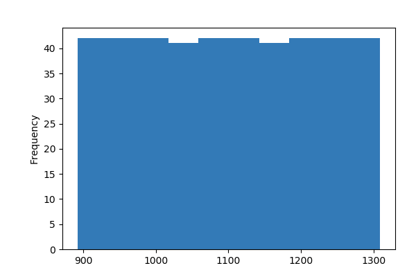

**Common Values**

| Value | Count | Frequency (%) |  |
| --- | --- | --- | --- |
| 1023 | 1 | 0.2% |  |
| 1128 | 1 | 0.2% |  |
| 1156 | 1 | 0.2% |  |
| 1157 | 1 | 0.2% |  |
| 1158 | 1 | 0.2% |  |
| 1159 | 1 | 0.2% |  |
| 1160 | 1 | 0.2% |  |
| 1161 | 1 | 0.2% |  |
| 1162 | 1 | 0.2% |  |
| 1163 | 1 | 0.2% |  |
| Other values (408) | 408 | 97.6% |  |

**Extreme Values**

Minimum 5 values

| Value | Count | Frequency (%) |  |
| --- | --- | --- | --- |
| 892 | 1 | 0.2% |  |
| 893 | 1 | 0.2% |  |
| 894 | 1 | 0.2% |  |
| 895 | 1 | 0.2% |  |
| 896 | 1 | 0.2% |  |

Maximum 5 values

| Value | Count | Frequency (%) |  |
| --- | --- | --- | --- |
| 1305 | 1 | 0.2% |  |
| 1306 | 1 | 0.2% |  |
| 1307 | 1 | 0.2% |  |
| 1308 | 1 | 0.2% |  |
| 1309 | 1 | 0.2% |  |

Pclass  
Numeric

| Distinct count | 3 |
| --- | --- |
| Unique (%) | 0.7% |
| Missing (%) | 0.0% |
| Missing (n) | 0 |
| Infinite (%) | 0.0% |
| Infinite (n) | 0 |

| Mean | 2.2656 |
| --- | --- |
| Minimum | 1 |
| Maximum | 3 |
| Zeros (%) | 0.0% |

Toggle details

**Statistics**

Quantile statistics

| Minimum | 1 |
| --- | --- |
| 5-th percentile | 1 |
| Q1 | 1 |
| Median | 3 |
| Q3 | 3 |
| 95-th percentile | 3 |
| Maximum | 3 |
| Range | 2 |
| Interquartile range | 2 |

Descriptive statistics

| Standard deviation | 0.84184 |
| --- | --- |
| Coef of variation | 0.37158 |
| Kurtosis | -1.3827 |
| Mean | 2.2656 |
| MAD | 0.76608 |
| Skewness | -0.53417 |
| Sum | 947 |
| Variance | 0.70869 |
| Memory size | 3.4 KiB |

**Histogram**

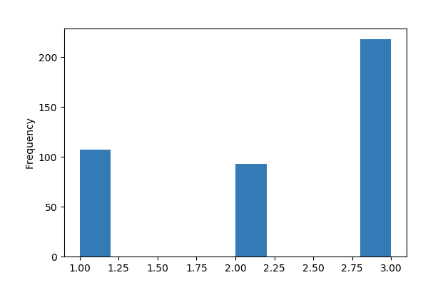

**Common Values**

| Value | Count | Frequency (%) |  |
| --- | --- | --- | --- |
| 3 | 218 | 52.2% |  |
| 1 | 107 | 25.6% |  |
| 2 | 93 | 22.2% |  |

**Extreme Values**

Minimum 5 values

| Value | Count | Frequency (%) |  |
| --- | --- | --- | --- |
| 1 | 107 | 25.6% |  |
| 2 | 93 | 22.2% |  |
| 3 | 218 | 52.2% |  |

Maximum 5 values

| Value | Count | Frequency (%) |  |
| --- | --- | --- | --- |
| 1 | 107 | 25.6% |  |
| 2 | 93 | 22.2% |  |
| 3 | 218 | 52.2% |  |

Name  
Categorical, Unique

| First 3 values |
| --- |
| Schmidt, Mr. August |
| Oliva y Ocana, Dona. Fermina |
| Olsen, Master. Artur Karl |

| Last 3 values |
| --- |
| Roth, Miss. Sarah A |
| Jonsson, Mr. Nils Hilding |
| Gale, Mr. Harry |

Toggle details

First 10 values

| Value | Count | Frequency (%) |  |
| --- | --- | --- | --- |
| Abbott, Master. Eugene Joseph | 1 | 0.2% |  |
| Abelseth, Miss. Karen Marie | 1 | 0.2% |  |
| Abelseth, Mr. Olaus Jorgensen | 1 | 0.2% |  |
| Abrahamsson, Mr. Abraham August Johannes | 1 | 0.2% |  |
| Abrahim, Mrs. Joseph (Sophie Halaut Easu) | 1 | 0.2% |  |

Last 10 values

| Value | Count | Frequency (%) |  |
| --- | --- | --- | --- |
| de Brito, Mr. Jose Joaquim | 1 | 0.2% |  |
| de Messemaeker, Mr. Guillaume Joseph | 1 | 0.2% |  |
| del Carlo, Mrs. Sebastiano (Argenia Genovesi) | 1 | 0.2% |  |
| van Billiard, Master. James William | 1 | 0.2% |  |
| van Billiard, Master. Walter John | 1 | 0.2% |  |

Sex  
Categorical

| Distinct count | 2 |
| --- | --- |
| Unique (%) | 0.5% |
| Missing (%) | 0.0% |
| Missing (n) | 0 |

| male | 266 |
| --- | --- |
| female | 152 |

Toggle details

| Value | Count | Frequency (%) |  |
| --- | --- | --- | --- |
| male | 266 | 63.6% |  |
| female | 152 | 36.4% |  |

Age  
Numeric

| Distinct count | 80 |
| --- | --- |
| Unique (%) | 19.1% |
| Missing (%) | 20.6% |
| Missing (n) | 86 |
| Infinite (%) | 0.0% |
| Infinite (n) | 0 |

| Mean | 30.273 |
| --- | --- |
| Minimum | 0.17 |
| Maximum | 76 |
| Zeros (%) | 0.0% |

Toggle details

**Statistics**

Quantile statistics

| Minimum | 0.17 |
| --- | --- |
| 5-th percentile | 8 |
| Q1 | 21 |
| Median | 27 |
| Q3 | 39 |
| 95-th percentile | 57 |
| Maximum | 76 |
| Range | 75.83 |
| Interquartile range | 18 |

Descriptive statistics

| Standard deviation | 14.181 |
| --- | --- |
| Coef of variation | 0.46845 |
| Kurtosis | 0.083783 |
| Mean | 30.273 |
| MAD | 11.172 |
| Skewness | 0.45736 |
| Sum | 10050 |
| Variance | 201.11 |
| Memory size | 3.4 KiB |

**Histogram**

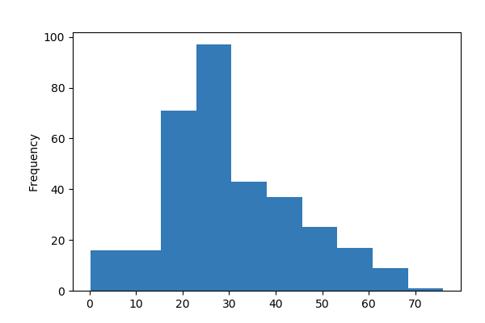

**Common Values**

| Value | Count | Frequency (%) |  |
| --- | --- | --- | --- |
| 24.0 | 17 | 4.1% |  |
| 21.0 | 17 | 4.1% |  |
| 22.0 | 16 | 3.8% |  |
| 30.0 | 15 | 3.6% |  |
| 18.0 | 13 | 3.1% |  |
| 27.0 | 12 | 2.9% |  |
| 26.0 | 12 | 2.9% |  |
| 25.0 | 11 | 2.6% |  |
| 23.0 | 11 | 2.6% |  |
| 29.0 | 10 | 2.4% |  |
| Other values (69) | 198 | 47.4% |  |
| (Missing) | 86 | 20.6% |  |

**Extreme Values**

Minimum 5 values

| Value | Count | Frequency (%) |  |
| --- | --- | --- | --- |
| 0.17 | 1 | 0.2% |  |
| 0.33 | 1 | 0.2% |  |
| 0.75 | 1 | 0.2% |  |
| 0.83 | 1 | 0.2% |  |
| 0.92 | 1 | 0.2% |  |

Maximum 5 values

| Value | Count | Frequency (%) |  |
| --- | --- | --- | --- |
| 62.0 | 1 | 0.2% |  |
| 63.0 | 2 | 0.5% |  |
| 64.0 | 3 | 0.7% |  |
| 67.0 | 1 | 0.2% |  |
| 76.0 | 1 | 0.2% |  |

SibSp  
Numeric

| Distinct count | 7 |
| --- | --- |
| Unique (%) | 1.7% |
| Missing (%) | 0.0% |
| Missing (n) | 0 |
| Infinite (%) | 0.0% |
| Infinite (n) | 0 |

| Mean | 0.44737 |
| --- | --- |
| Minimum | 0 |
| Maximum | 8 |
| Zeros (%) | 67.7% |

Toggle details

**Statistics**

Quantile statistics

| Minimum | 0 |
| --- | --- |
| 5-th percentile | 0 |
| Q1 | 0 |
| Median | 0 |
| Q3 | 1 |
| 95-th percentile | 2 |
| Maximum | 8 |
| Range | 8 |
| Interquartile range | 1 |

Descriptive statistics

| Standard deviation | 0.89676 |
| --- | --- |
| Coef of variation | 2.0045 |
| Kurtosis | 26.499 |
| Mean | 0.44737 |
| MAD | 0.60577 |
| Skewness | 4.1683 |
| Sum | 187 |
| Variance | 0.80418 |
| Memory size | 3.4 KiB |

**Histogram**

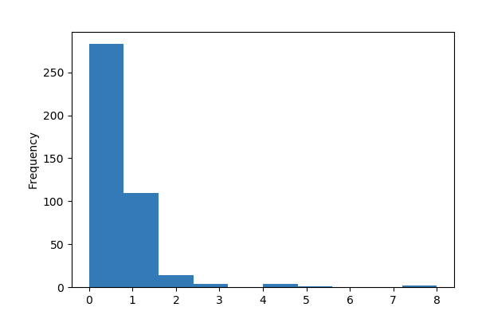

**Common Values**

| Value | Count | Frequency (%) |  |
| --- | --- | --- | --- |
| 0 | 283 | 67.7% |  |
| 1 | 110 | 26.3% |  |
| 2 | 14 | 3.3% |  |
| 4 | 4 | 1.0% |  |
| 3 | 4 | 1.0% |  |
| 8 | 2 | 0.5% |  |
| 5 | 1 | 0.2% |  |

**Extreme Values**

Minimum 5 values

| Value | Count | Frequency (%) |  |
| --- | --- | --- | --- |
| 0 | 283 | 67.7% |  |
| 1 | 110 | 26.3% |  |
| 2 | 14 | 3.3% |  |
| 3 | 4 | 1.0% |  |
| 4 | 4 | 1.0% |  |

Maximum 5 values

| Value | Count | Frequency (%) |  |
| --- | --- | --- | --- |
| 2 | 14 | 3.3% |  |
| 3 | 4 | 1.0% |  |
| 4 | 4 | 1.0% |  |
| 5 | 1 | 0.2% |  |
| 8 | 2 | 0.5% |  |

Parch  
Numeric

| Distinct count | 8 |
| --- | --- |
| Unique (%) | 1.9% |
| Missing (%) | 0.0% |
| Missing (n) | 0 |
| Infinite (%) | 0.0% |
| Infinite (n) | 0 |

| Mean | 0.39234 |
| --- | --- |
| Minimum | 0 |
| Maximum | 9 |
| Zeros (%) | 77.5% |

Toggle details

**Statistics**

Quantile statistics

| Minimum | 0 |
| --- | --- |
| 5-th percentile | 0 |
| Q1 | 0 |
| Median | 0 |
| Q3 | 0 |
| 95-th percentile | 2 |
| Maximum | 9 |
| Range | 9 |
| Interquartile range | 0 |

Descriptive statistics

| Standard deviation | 0.98143 |
| --- | --- |
| Coef of variation | 2.5014 |
| Kurtosis | 31.413 |
| Mean | 0.39234 |
| MAD | 0.60823 |
| Skewness | 4.6545 |
| Sum | 164 |
| Variance | 0.9632 |
| Memory size | 3.4 KiB |

**Histogram**

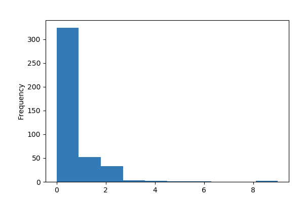

**Common Values**

| Value | Count | Frequency (%) |  |
| --- | --- | --- | --- |
| 0 | 324 | 77.5% |  |
| 1 | 52 | 12.4% |  |
| 2 | 33 | 7.9% |  |
| 3 | 3 | 0.7% |  |
| 9 | 2 | 0.5% |  |
| 4 | 2 | 0.5% |  |
| 6 | 1 | 0.2% |  |
| 5 | 1 | 0.2% |  |

**Extreme Values**

Minimum 5 values

| Value | Count | Frequency (%) |  |
| --- | --- | --- | --- |
| 0 | 324 | 77.5% |  |
| 1 | 52 | 12.4% |  |
| 2 | 33 | 7.9% |  |
| 3 | 3 | 0.7% |  |
| 4 | 2 | 0.5% |  |

Maximum 5 values

| Value | Count | Frequency (%) |  |
| --- | --- | --- | --- |
| 3 | 3 | 0.7% |  |
| 4 | 2 | 0.5% |  |
| 5 | 1 | 0.2% |  |
| 6 | 1 | 0.2% |  |
| 9 | 2 | 0.5% |  |

Ticket  
Categorical

| Distinct count | 363 |
| --- | --- |
| Unique (%) | 86.8% |
| Missing (%) | 0.0% |
| Missing (n) | 0 |

| PC 17608 | 5 |
| --- | --- |
| 113503 | 4 |
| CA. 2343 | 4 |
| Other values (360) | 405 |

Toggle details

| Value | Count | Frequency (%) |  |
| --- | --- | --- | --- |
| PC 17608 | 5 | 1.2% |  |
| 113503 | 4 | 1.0% |  |
| CA. 2343 | 4 | 1.0% |  |
| 220845 | 3 | 0.7% |  |
| PC 17483 | 3 | 0.7% |  |
| 347077 | 3 | 0.7% |  |
| 16966 | 3 | 0.7% |  |
| C.A. 31029 | 3 | 0.7% |  |
| SOTON/O.Q. 3101315 | 3 | 0.7% |  |
| 33638 | 2 | 0.5% |  |
| Other values (353) | 385 | 92.1% |  |

Fare  
Numeric

| Distinct count | 170 |
| --- | --- |
| Unique (%) | 40.7% |
| Missing (%) | 0.2% |
| Missing (n) | 1 |
| Infinite (%) | 0.0% |
| Infinite (n) | 0 |

| Mean | 35.627 |
| --- | --- |
| Minimum | 0 |
| Maximum | 512.33 |
| Zeros (%) | 0.5% |

Toggle details

**Statistics**

Quantile statistics

| Minimum | 0 |
| --- | --- |
| 5-th percentile | 7.2292 |
| Q1 | 7.8958 |
| Median | 14.454 |
| Q3 | 31.5 |
| 95-th percentile | 151.55 |
| Maximum | 512.33 |
| Range | 512.33 |
| Interquartile range | 23.604 |

Descriptive statistics

| Standard deviation | 55.908 |
| --- | --- |
| Coef of variation | 1.5692 |
| Kurtosis | 17.922 |
| Mean | 35.627 |
| MAD | 33.294 |
| Skewness | 3.6872 |
| Sum | 14857 |
| Variance | 3125.7 |
| Memory size | 3.4 KiB |

**Histogram**

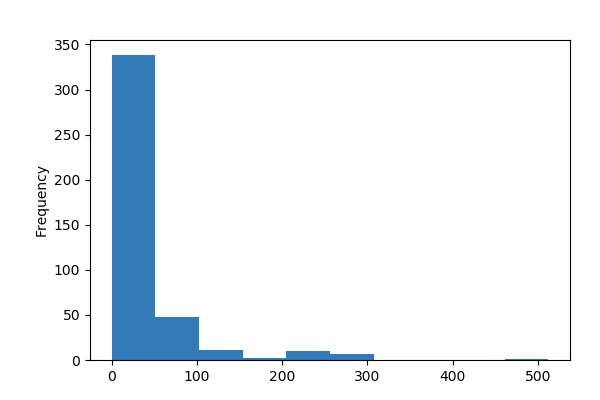

**Common Values**

| Value | Count | Frequency (%) |  |
| --- | --- | --- | --- |
| 7.75 | 21 | 5.0% |  |
| 26.0 | 19 | 4.5% |  |
| 8.05 | 17 | 4.1% |  |
| 13.0 | 17 | 4.1% |  |
| 7.8958 | 11 | 2.6% |  |
| 10.5 | 11 | 2.6% |  |
| 7.775 | 10 | 2.4% |  |
| 7.2292 | 9 | 2.2% |  |
| 7.225 | 9 | 2.2% |  |
| 7.8542 | 8 | 1.9% |  |
| Other values (159) | 285 | 68.2% |  |

**Extreme Values**

Minimum 5 values

| Value | Count | Frequency (%) |  |
| --- | --- | --- | --- |
| 0.0 | 2 | 0.5% |  |
| 3.1708 | 1 | 0.2% |  |
| 6.4375 | 2 | 0.5% |  |
| 6.4958 | 1 | 0.2% |  |
| 6.95 | 1 | 0.2% |  |

Maximum 5 values

| Value | Count | Frequency (%) |  |
| --- | --- | --- | --- |
| 227.525 | 1 | 0.2% |  |
| 247.5208 | 1 | 0.2% |  |
| 262.375 | 5 | 1.2% |  |
| 263.0 | 2 | 0.5% |  |
| 512.3292 | 1 | 0.2% |  |

Cabin  
Categorical

| Distinct count | 77 |
| --- | --- |
| Unique (%) | 18.4% |
| Missing (%) | 78.2% |
| Missing (n) | 327 |

| B57 B59 B63 B66 | 3 |
| --- | --- |
| C6 | 2 |
| C89 | 2 |
| Other values (73) | 84 |
| (Missing) | 327 |

Toggle details

| Value | Count | Frequency (%) |  |
| --- | --- | --- | --- |
| B57 B59 B63 B66 | 3 | 0.7% |  |
| C6 | 2 | 0.5% |  |
| C89 | 2 | 0.5% |  |
| C55 C57 | 2 | 0.5% |  |
| F4 | 2 | 0.5% |  |
| C78 | 2 | 0.5% |  |
| A34 | 2 | 0.5% |  |
| E34 | 2 | 0.5% |  |
| C116 | 2 | 0.5% |  |
| C23 C25 C27 | 2 | 0.5% |  |
| Other values (66) | 70 | 16.7% |  |
| (Missing) | 327 | 78.2% |  |

Embarked  
Categorical

| Distinct count | 3 |
| --- | --- |
| Unique (%) | 0.7% |
| Missing (%) | 0.0% |
| Missing (n) | 0 |

| S | 270 |
| --- | --- |
| C | 102 |
| Q | 46 |

Toggle details

| Value | Count | Frequency (%) |  |
| --- | --- | --- | --- |
| S | 270 | 64.6% |  |
| C | 102 | 24.4% |  |
| Q | 46 | 11.0% |  |

Correlations

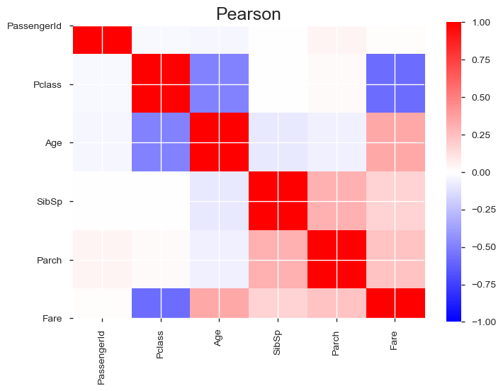

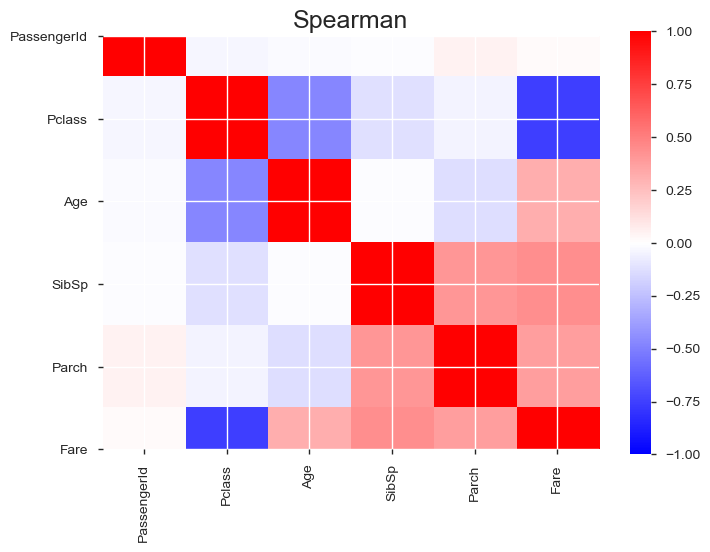

Sample

|  | PassengerId | Pclass | Name | Sex | Age | SibSp | Parch | Ticket | Fare | Cabin | Embarked |
| --- | --- | --- | --- | --- | --- | --- | --- | --- | --- | --- | --- |
| 0 | 892 | 3 | Kelly, Mr. James | male | 34.5 | 0 | 0 | 330911 | 7.8292 | NaN | Q |
| 1 | 893 | 3 | Wilkes, Mrs. James (Ellen Needs) | female | 47.0 | 1 | 0 | 363272 | 7.0000 | NaN | S |
| 2 | 894 | 2 | Myles, Mr. Thomas Francis | male | 62.0 | 0 | 0 | 240276 | 9.6875 | NaN | Q |
| 3 | 895 | 3 | Wirz, Mr. Albert | male | 27.0 | 0 | 0 | 315154 | 8.6625 | NaN | S |
| 4 | 896 | 3 | Hirvonen, Mrs. Alexander (Helga E Lindqvist) | female | 22.0 | 1 | 1 | 3101298 | 12.2875 | NaN | S |

```python
profileTest
```

```python
# We take all the features details from our profiling so we can use it later to get the values we need.
PassengersTest = profileTest.get_description()["variables"].loc["PassengerId",:]
PclassTest = profileTest.get_description()["variables"].loc["Pclass",:]
PclassFreqTest = profileTest.get_description()["freq"].get("Pclass")
NameTest = profileTest.get_description()["variables"].loc["Name",:]
SexTest = profileTest.get_description()["variables"].loc["Sex",:]
SexFreqTest = profileTest.get_description()["freq"].get("Sex")
AgeTest = profileTest.get_description()["variables"].loc["Age",:]
AgeFreqTest = profileTest.get_description()["freq"].get("Age")
SibSpTest = profileTest.get_description()["variables"].loc["SibSp",:]
SibSpFreqTest = profileTest.get_description()["freq"].get("SibSp")
ParchTest = profileTest.get_description()["variables"].loc["Parch",:]
ParchFreqTest = profileTest.get_description()["freq"].get("Parch")

TicketTest = profileTest.get_description()["variables"].loc["Ticket",:]
TicketFreqTest = profileTest.get_description()["freq"].get("Ticket")

FareTest = profileTest.get_description()["variables"].loc["Fare",:]
FareFreqTest = profileTest.get_description()["freq"].get("Fare")

CabinTest = profileTest.get_description()["variables"].loc["Cabin",:]
CabinFreqTest = profileTest.get_description()["freq"].get("Cabin")

EmbarkedTest = profileTest.get_description()["variables"].loc["Embarked",:]
EmbarkedFreqTest = profileTest.get_description()["freq"].get("Embarked")
```

# Data Visualization

### Features details:

In this section we will summarize all our data features:

1. Survival: We have 2 values availables - 0 = Didn't Survived, 1 = Survived
2. Pclass: We have 3 values: 1 = 1st, 2 = 2nd, 3 = 3rd
3. Sex: The ex of the passenger - Male or Female
4. Age: The age of the passenger in years.
5. Sibsp: The number of siblings / spouses aboard the Titanic. The dataset defines family relations in this way
6. Parch: The number of parents / children aboard the Titanic. The dataset defines family relations in this way
7. Ticket: The nuber of the passenger ticket.
8. Fare: the fate the passenger payed
9. Cabin: Cabin number where the passnger slept
10. Embarked: We have 3 diffrent embarked Port: C = Cherbourg, Q = Queenstown, S = Southampton

Some children travelled only with a nanny, therefore parch=0 for them

```python
# FEATUERS = ['Pclass', 'Name', 'Sex', 'Age', 'SibSp','Parch', 'Ticket', 'Fare', 'Cabin', 'Embarked']
# X = TrainDF.loc[:,FEATUERS]
# y = TrainDF.loc[:,"Survived"]
# # print(len(X))

# dataframe = pd.DataFrame(X, columns=FEATUERS)
# dataframe
# pd.plotting.scatter_matrix(dataframe, c=y, figsize=(15, 15),
#                            marker='o', hist_kwds={'bins': 20}, s=60,
#                            alpha=.8)
# plt.show()
```

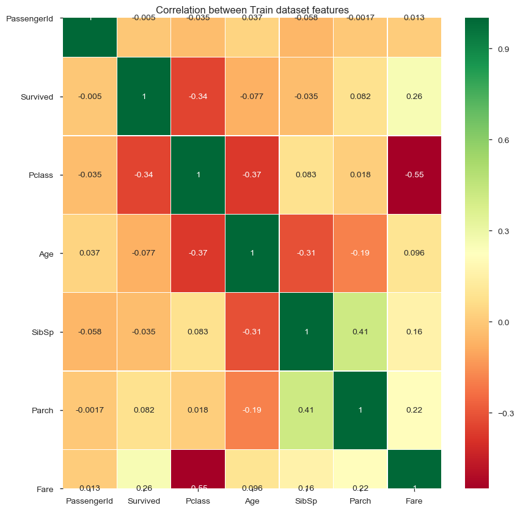

```python
sns.heatmap(TrainDF.corr(),annot=True,cmap='RdYlGn',linewidths=0.2) #data.corr()-->correlation matrix
fig=plt.gcf()
fig.set_size_inches(10,10)
plt.title('Correlation between Train dataset features');
```

##### Corralation results:

###### Passengers details

```python
print ("There are", Passengers["count"] + PassengersTest["count"]  , "passengers on the Titanic ship")
```

```
There are 1309 passengers on the Titanic ship
```

###### Survived details - Train dataset only

```python
print (SurvivedFreq[1], "passengers survived", ", Whereas", SurvivedFreq[0],"passengers didn't Survived")
print("Total % of dead from all passengers:", "{:.1f}".format( (SurvivedFreq[0] * 100) / Survived["count"]),"%")
```

```
342 passengers survived , Whereas 549 passengers didn't Survived
Total % of dead from all passengers: 61.6 %
```

###### Pclass details

```python
print("There are 3 Diffrend of ticket classes.", "\nIn the ship there were:\n", PclassFreq[1] + PclassFreqTest[1], "passengers in class 1\n" , PclassFreq[2] + PclassFreqTest[2], "passengers in class 2\n", PclassFreq[3] + PclassFreqTest[3], "passengers in class 3")
```

```
There are 3 Diffrend of ticket classes.
In the ship there were:
 323 passengers in class 1
 277 passengers in class 2
 709 passengers in class 3
```

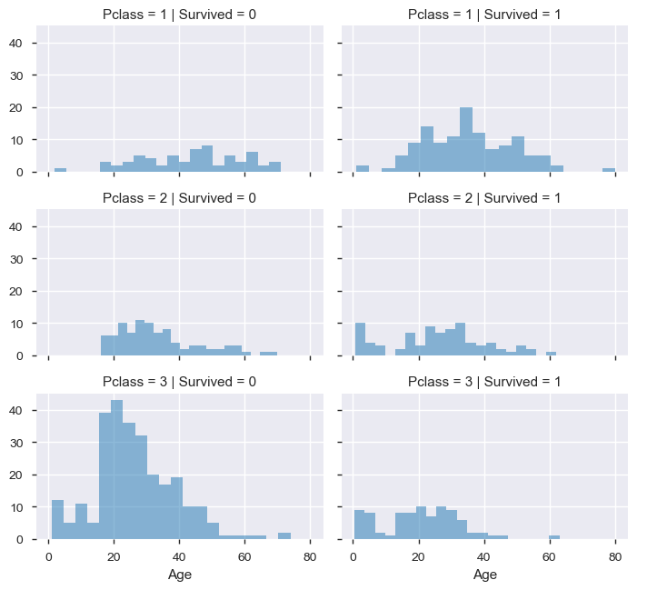

```python
# Train dataset only
grid = sns.FacetGrid(TrainDF, col='Survived', row='Pclass', height=2.2, aspect=1.6)
grid.map(plt.hist, 'Age', alpha=.5, bins=20)
grid.add_legend();
```

```python
pclass3 = TrainDF.loc[TrainDF['Pclass'] == 3]
list3 = pclass3['Survived'].value_counts()
print("Didn't survived from PClass 3:", list3[0]/len(pclass3)*100, "%")

pclass2 = TrainDF.loc[TrainDF['Pclass'] == 2]
list2 = pclass2['Survived'].value_counts()
print("Didn't survived from PClass 2:", list2[0]/len(pclass2)*100, "%")

pclass1 = TrainDF.loc[TrainDF['Pclass'] == 1]
list1 = pclass1['Survived'].value_counts()
print("Didn't survived from PClass 1:", list1[0]/len(pclass1)*100, "%")
list1
```

```
Didn't survived from PClass 3: 75.76374745417516 %
Didn't survived from PClass 2: 52.71739130434783 %
Didn't survived from PClass 1: 37.03703703703704 %
```

```
1    136
0     80
Name: Survived, dtype: int64
```

###### Graph to see the correlation between PClass features to survived.

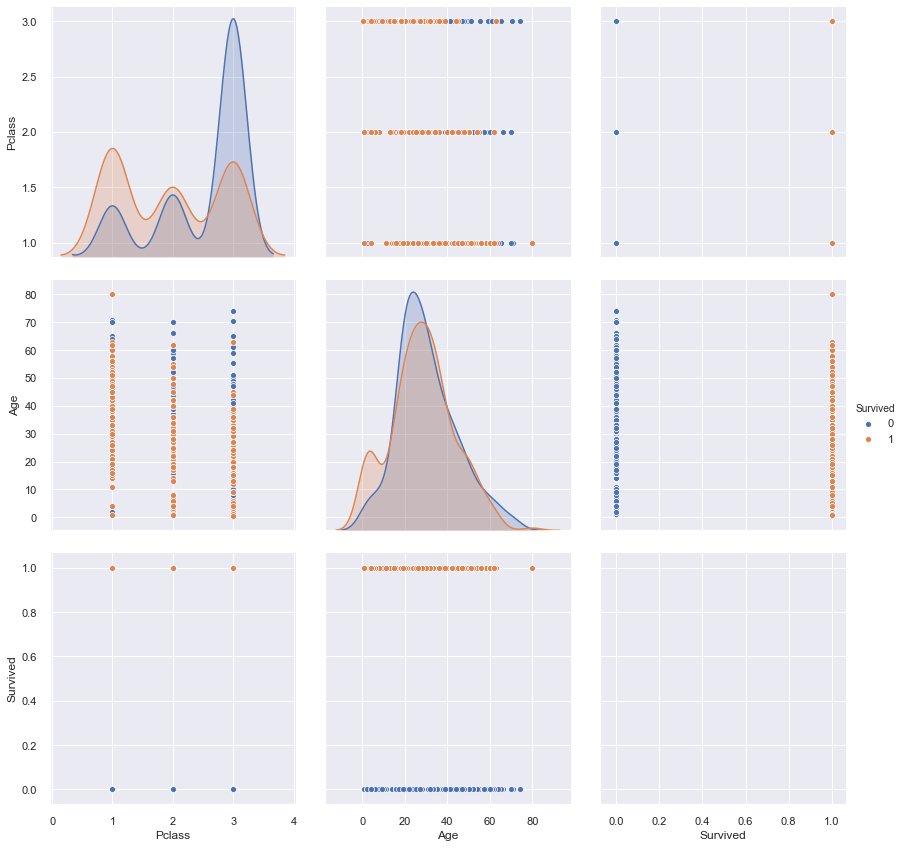

```python
features_new = ['Pclass', 'Age','Survived']
Q = TrainDF.loc[:, features_new] #define training features set
Z= TrainDF.loc[:,"Survived"] #define training label set
transformCategoricalFeatures(Q)

%matplotlib inline
import seaborn as sns; sns.set()
sns.pairplot(Q, hue='Survived', size=4);
```

###### Name details

- In this features we have only names so we will take from each name the passenger title and replace the column in our dataframe

Titles:

```python
combine = [TrainDF, TestDF]
for dataset in combine:
    dataset['Title'] = dataset.Name.str.extract(' ([A-Za-z]+)\.', expand=False)

pd.crosstab(TrainDF['Title'], TrainDF['Sex'])
```

| Sex Title | female | male |
| --- | --- | --- |
| Capt | 0 | 1 |
| Col | 0 | 2 |
| Countess | 1 | 0 |
| Don | 0 | 1 |
| Dr | 1 | 6 |
| Jonkheer | 0 | 1 |
| Lady | 1 | 0 |
| Major | 0 | 2 |
| Master | 0 | 40 |
| Miss | 182 | 0 |
| Mlle | 2 | 0 |
| Mme | 1 | 0 |
| Mr | 0 | 517 |
| Mrs | 125 | 0 |
| Ms | 1 | 0 |
| Rev | 0 | 6 |
| Sir | 0 | 1 |

```python
# We can replace many titles with a more common name or classify them as Rare.
for dataset in combine:
    dataset['Title'] = dataset['Title'].replace(['Lady', 'Countess','Capt', 'Col',\
 	'Don', 'Dr', 'Major', 'Rev', 'Sir', 'Jonkheer', 'Dona'], 'Rare')

    dataset['Title'] = dataset['Title'].replace('Mlle', 'Miss')
    dataset['Title'] = dataset['Title'].replace('Ms', 'Miss')
    dataset['Title'] = dataset['Title'].replace('Mme', 'Mrs')


TrainDF[['Title', 'Survived']].groupby(['Title'], as_index=False).mean().sort_values('Survived', ascending=False)
```

|  | Title | Survived |
| --- | --- | --- |
| 3 | Mrs | 0.793651 |
| 1 | Miss | 0.702703 |
| 0 | Master | 0.575000 |
| 4 | Rare | 0.347826 |
| 2 | Mr | 0.156673 |

###### Conclutions:

- We can see more then 70% from the Miss and Mrs on the ship survived
- only 15% from Mr title survived.
- women survived more then men.

###### Sex details

```python
print("There are", SexFreq[0] + SexFreqTest[0], "Male and", SexFreq[1] + SexFreqTest[1], "female on the ship")
```

```
There are 843 Male and 466 female on the ship
```

```python
# check survival only on Train dataset
TrainDF[["Sex", "Survived"]].groupby(['Sex'], as_index=False).mean().sort_values(by='Survived', ascending=False)
```

|  | Sex | Survived |
| --- | --- | --- |
| 0 | female | 0.742038 |
| 1 | male | 0.188908 |

###### Age details

```python
print("In the ship there are", Age["count"] + AgeTest["count"] , "diffrent ages.")
print("Train dataset: \n\tThere are", Age["n_missing"],"missing ages of passengers -","{:.2f}".format(Age["p_missing"] * 100),"% from the ages are missing\n")
print("Test dataset: \n\tThere are", AgeTest["n_missing"],"missing ages of passengers -","{:.2f}".format(AgeTest["p_missing"] * 100),"% from the ages are missing")
```

```
In the ship there are 1046 diffrent ages.
Train dataset:
	There are 177 missing ages of passengers - 19.87 % from the ages are missing

Test dataset:
	There are 86 missing ages of passengers - 20.57 % from the ages are missing
```

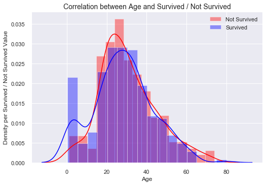

```python
### Plotting Numeric Features
# Figure initiation
fig = plt.figure(figsize=(18,12))

### Distribution per Survived / Not Survived Value
# Not Survived hist
sns.distplot(TrainDF.loc[TrainDF.Survived==0, "Age"].dropna(),
             color='red', label='Not Survived', ax=plt.subplot(222));
# Survived hist
sns.distplot(TrainDF.loc[TrainDF.Survived==1, "Age"].dropna(),
             color='blue', label='Survived', ax=plt.subplot(222));
# Adding Legend
plt.legend(loc='best')
# X-axis Label
plt.xlabel("Age");
# Y-axis Label
plt.ylabel('Density per Survived / Not Survived Value');
plt.title("Correlation between Age and Survived / Not Survived", fontsize=14)
```

```python
SibSp
SibSpFreq
Parch
ParchFreq
```

```
0    678
1    118
2     80
5      5
3      5
4      4
6      1
Name: Parch, dtype: int64
```

###### SibSp details

survived vs. not survived in SibSp feature

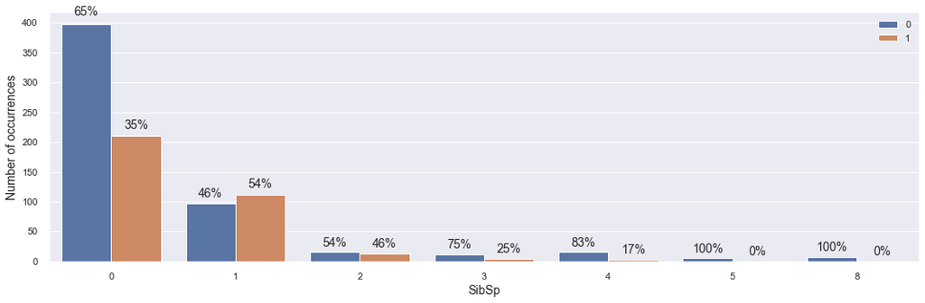

```python
plotForSibSpAndParch('SibSp')
```

###### Parch details

survived vs. not survived in Parch feature

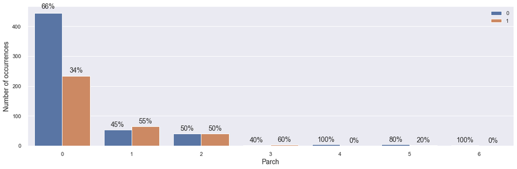

```python
plotForSibSpAndParch('Parch')
```

###### Ticket details

```python
Ticket
TicketFreq
```

```
347082        7
1601          7
CA. 2343      7
3101295       6
347088        6
             ..
349247        1
7553          1
A/4. 34244    1
349205        1
343276        1
Name: Ticket, Length: 681, dtype: int64
```